# 2020 Q

Jake Cavaiani

11/13/2020

### 2020

2020 (Moose, French, Poker, Vault, Stuart), and 2021 (Moose, French, Poker, Vault, Stuart), clean out of water points, potentially erroneous points collected, beaver dams, etc. and prepare to convert to continuous predicted discharge (Q) throuhgout the year.

2020 data is read in from DoD Project->2020 AK sensors->Discharge->Pressure Transducer->Water Level->“site”

NEON air pressure data to check time zone

## Comparing PTs

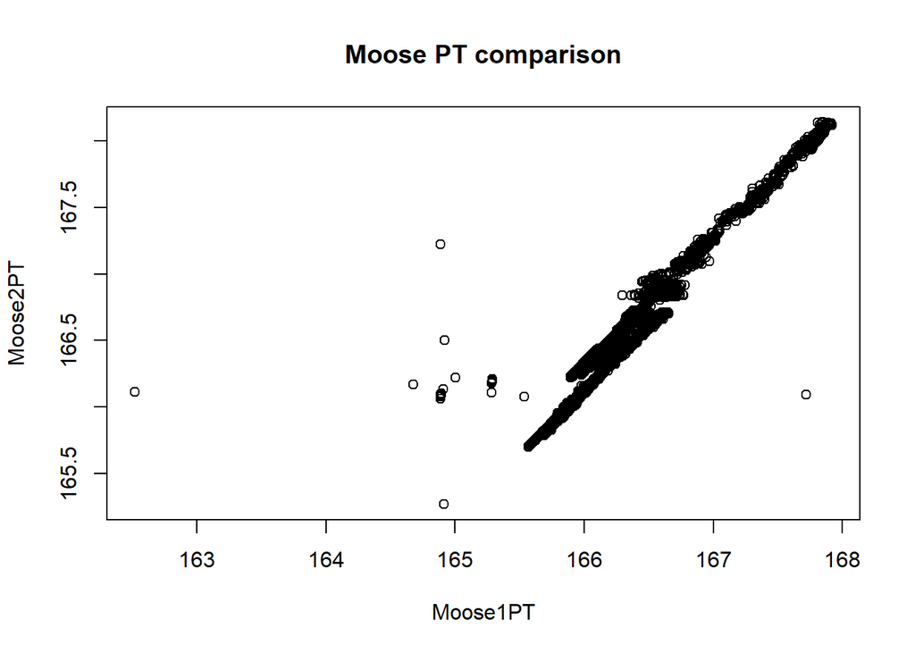

Some erroneous points but not bad. a slight shift

## Comparing FRCH

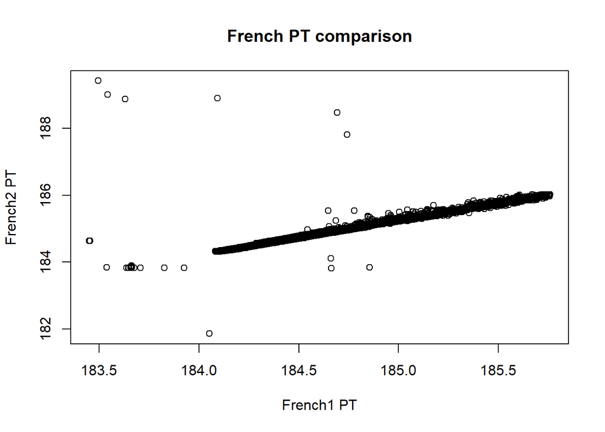

Pretty good, have to clean some of those points

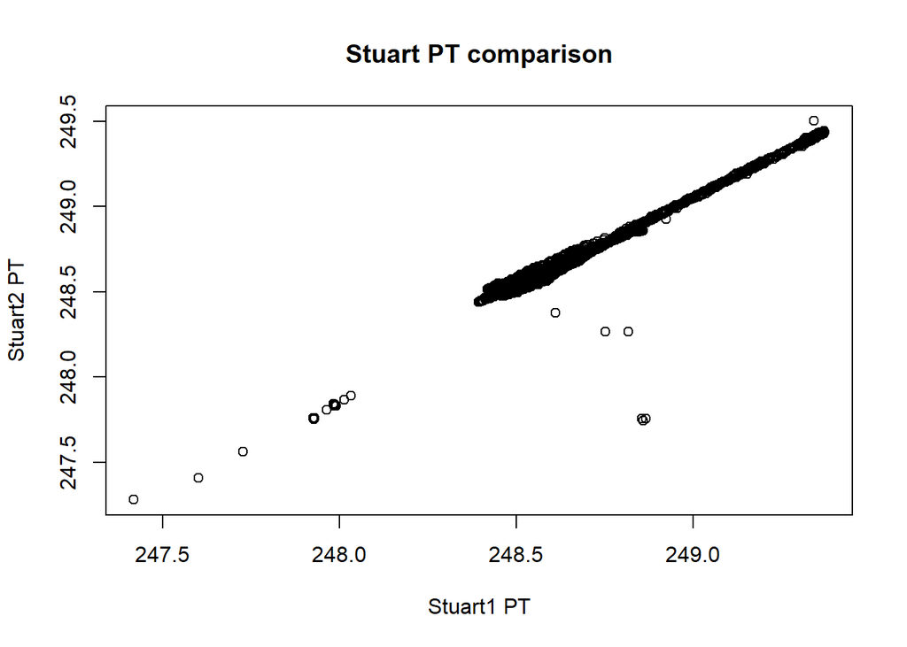

Same as French, some erroneous points that will need to be cleaned

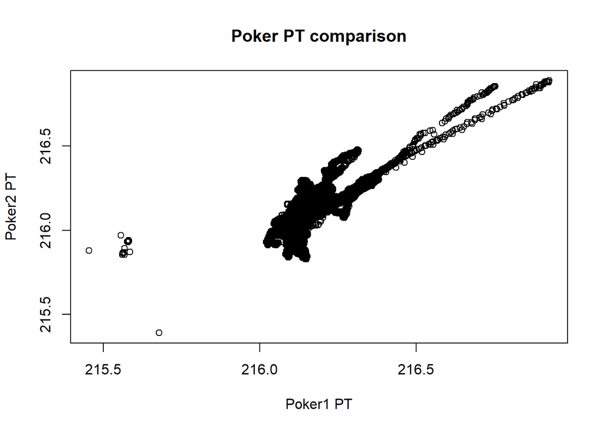

One PT is definitely more noisy

## Observed Discharge at all sites for 2020

Slugs and wading rods were used for 2020 observed Q

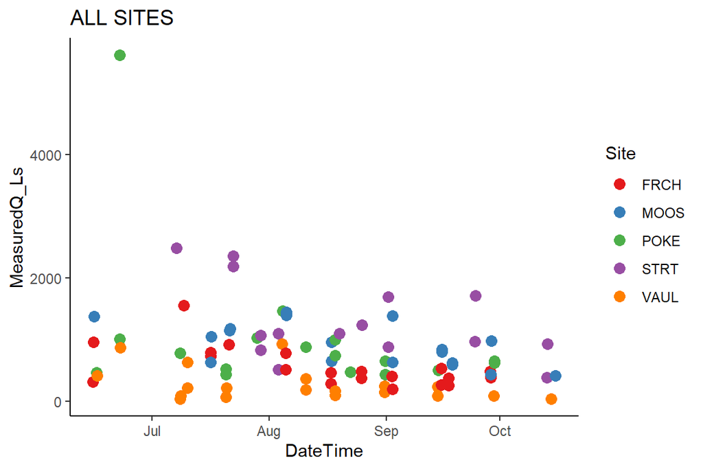

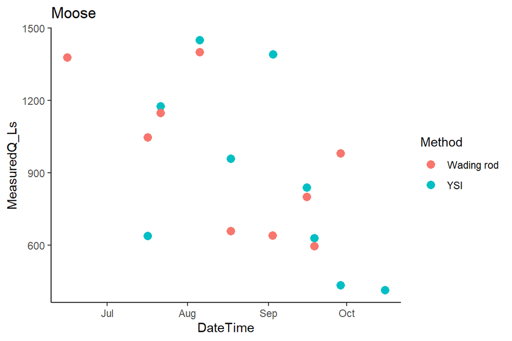

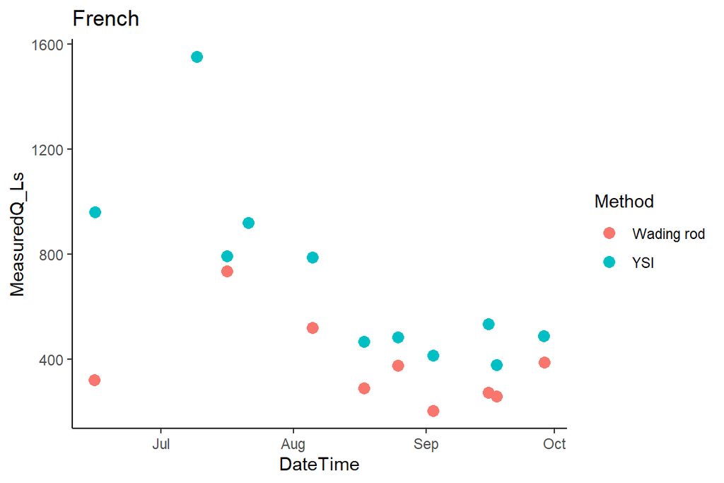

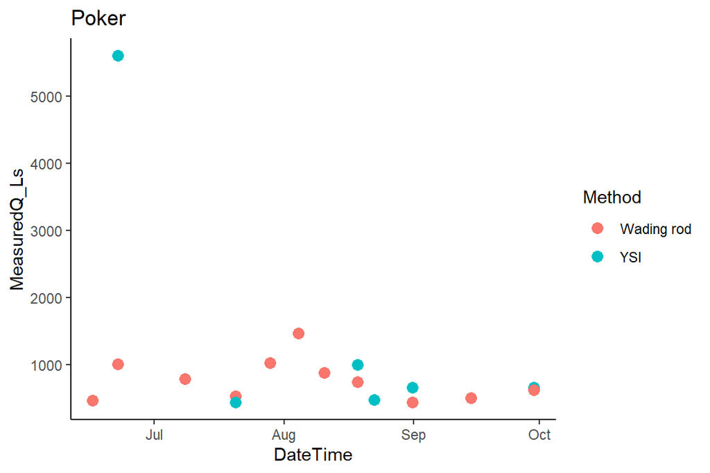

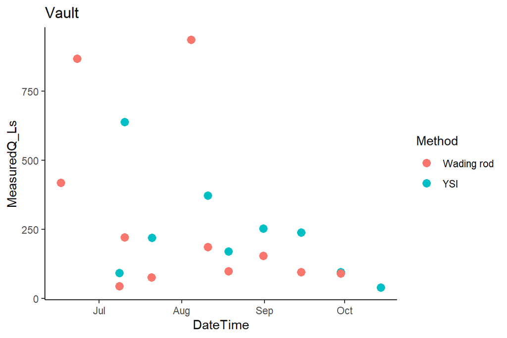

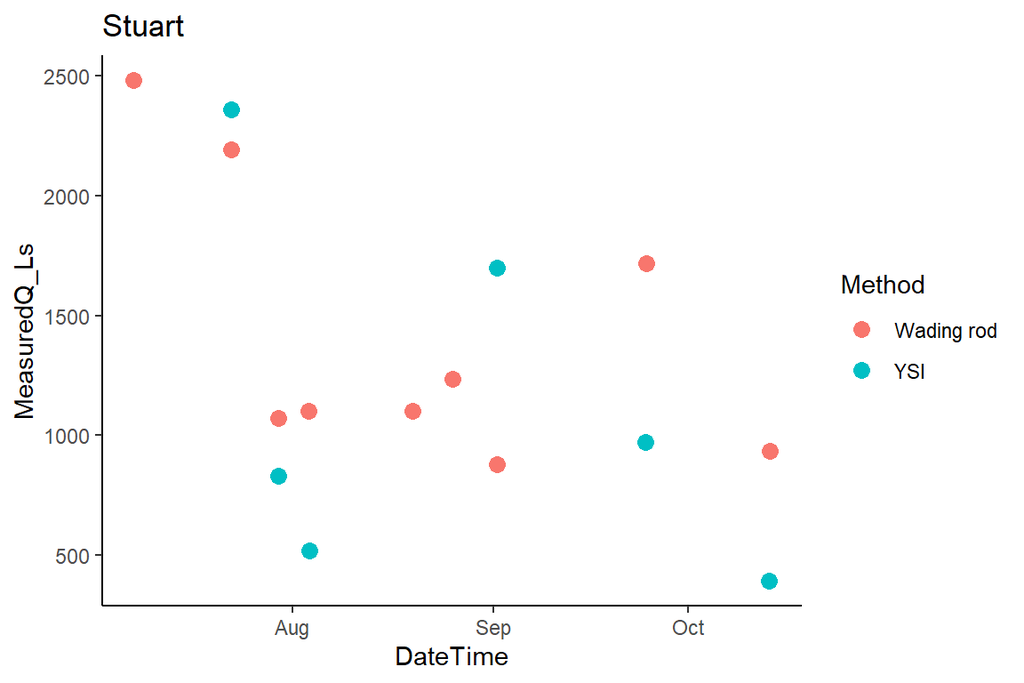

[figure not shown]

# Compare with NEON air pressure to verify time zone

## Raw Moose PT1

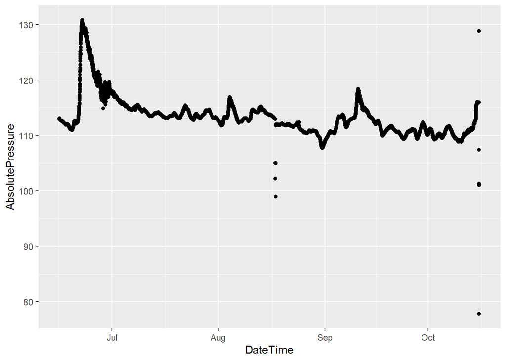

Noisy on the falling limb of first storm, potentially some out of water points in August and at the end of the season…Let the cleaning commence!

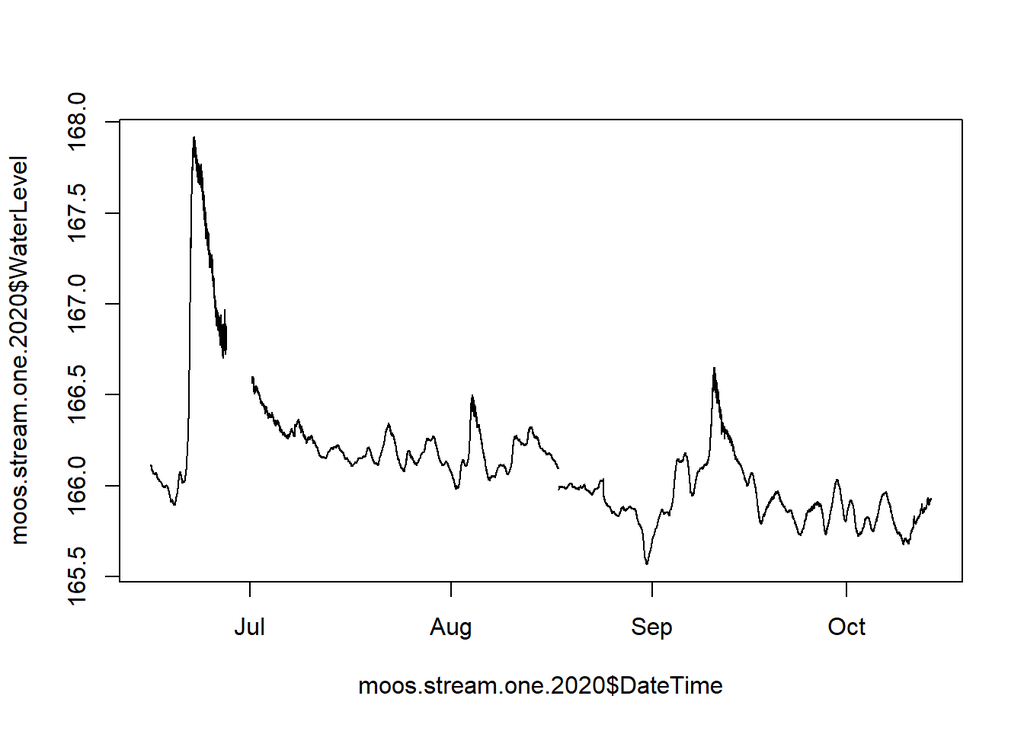

```
## [1] 166.093
```

```
## [1] 165.977
```

```
## [1] 0.116
```

[output not shown]

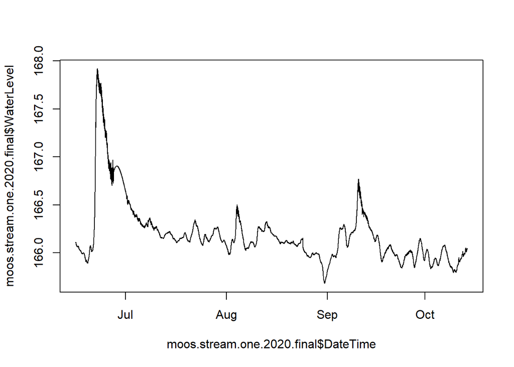

1. Clipped off data after 10/14 because thats when we took the PTs out
2. Set receding limb of first big storm in June to NA due to “noisy-ness”
3. clipped off errant points - vertical bars
4. After clipping off errant points the back half of the data after August 8/17 @ 07:00 needed to be shifted up so I took the difference of the not matched points of the data and added the difference to the data following the clip

## Raw Moose PT2

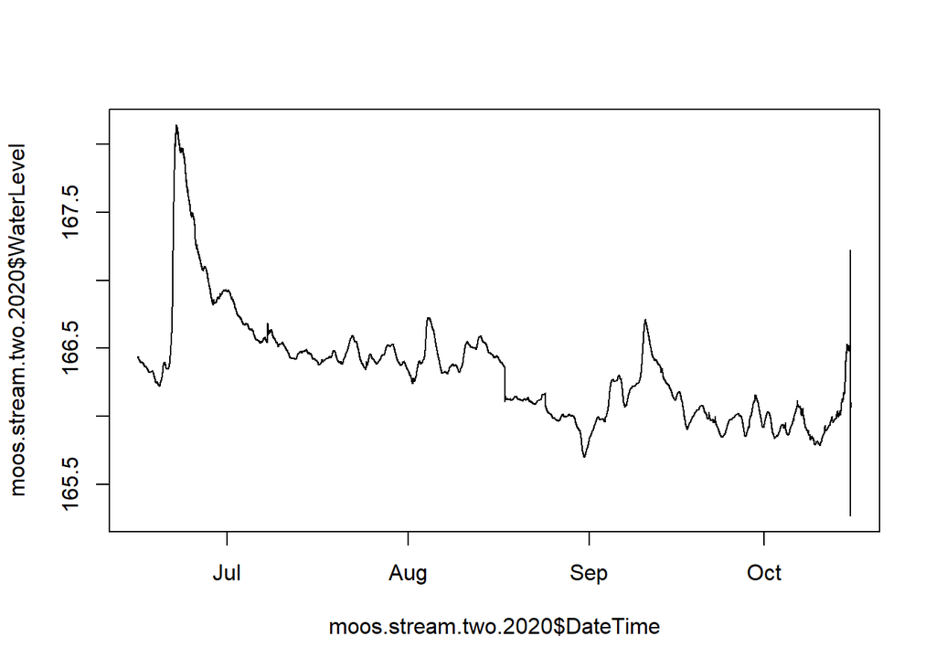

Need to adjust middle of August on and clip off out of water points associated with install or decomission

```
## [1] 166.361
```

```
## [1] 166.171
```

```
## [1] 0.19
```

[output not shown]

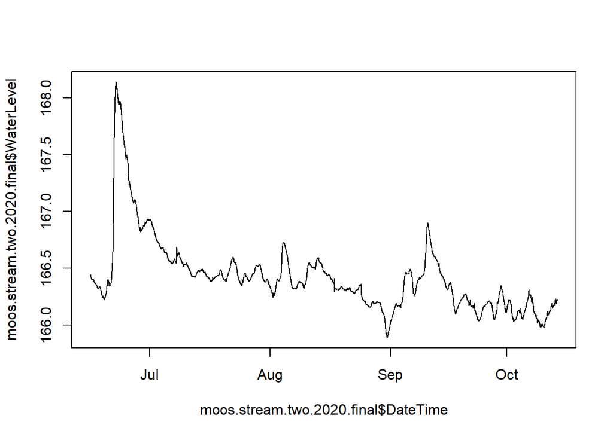

1. Clipped off data after 10/14 because thats when we took the PTs out
2. clipped off errant points (vertical bars)
3. After clipping off errant points the back half of the data after August 8/17 @ 07:00 needed to be shifted up so I took the difference of the not matched points of the data and added the difference to the data following the clip

Export PT data to csv in DoD_Discharge->PT_data->2020

Raw Rating Curve with MOOS PT1

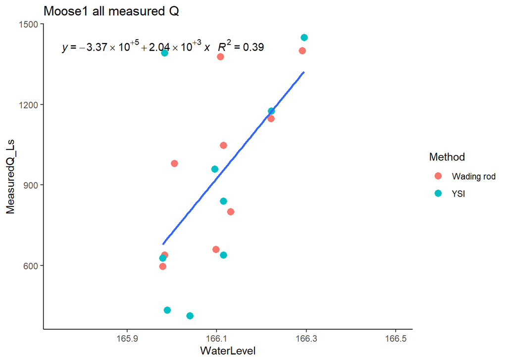

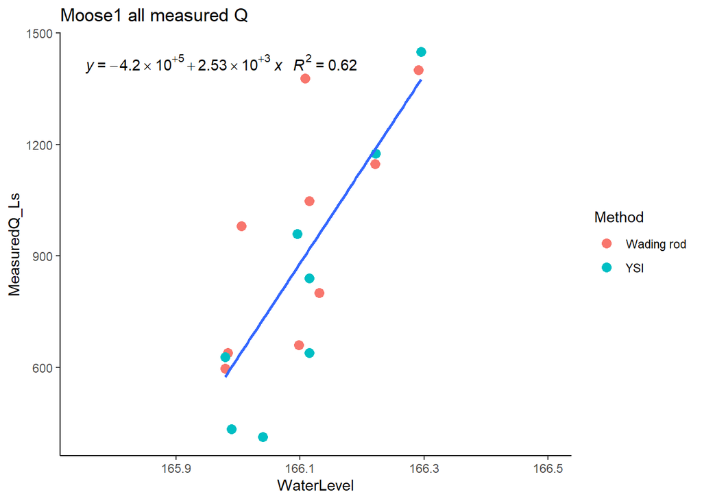

## Predict PT1 Q

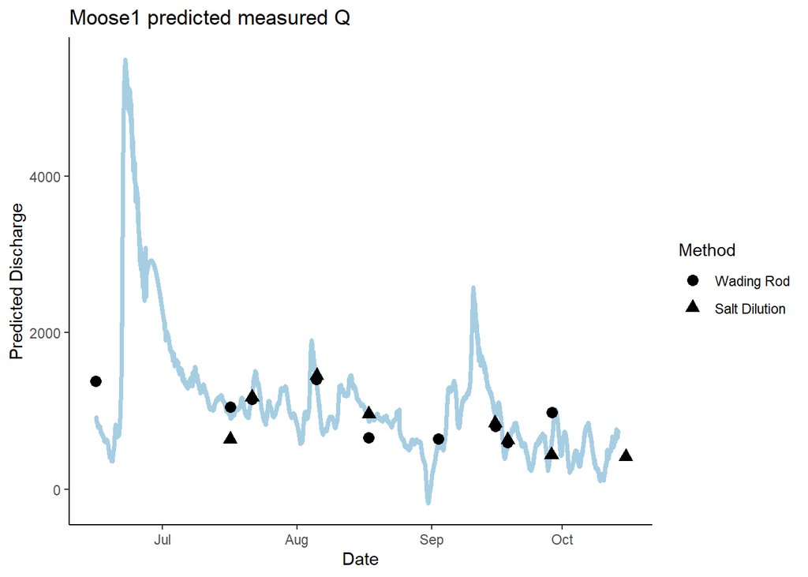

## Raw Rating Curve with MOOS PT2

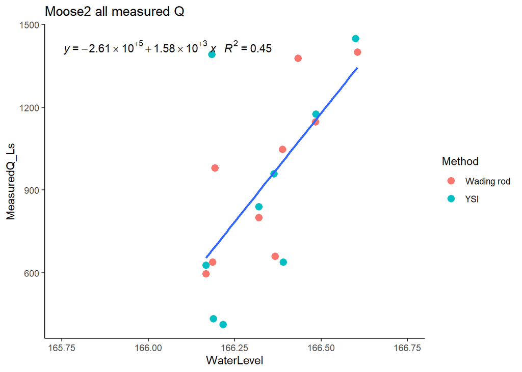

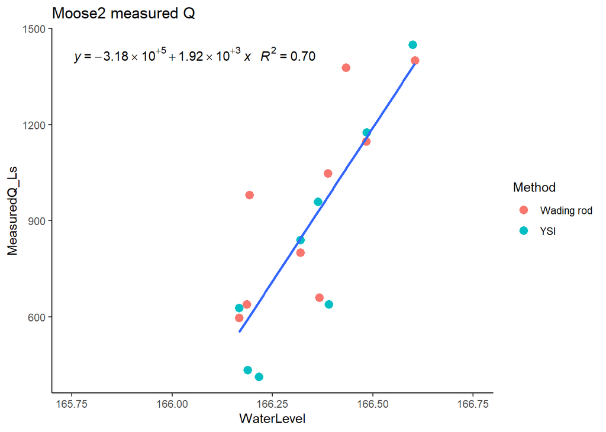

## Final Q for MOOS PT2

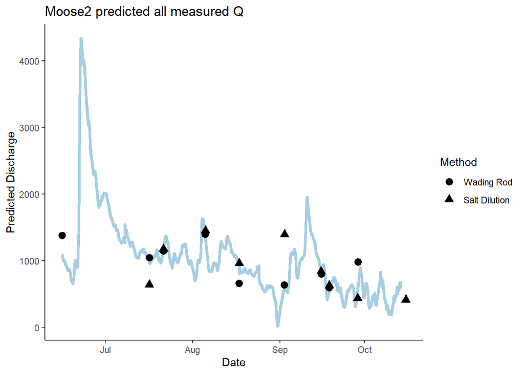

## Average of MOOS PT1 and PT2

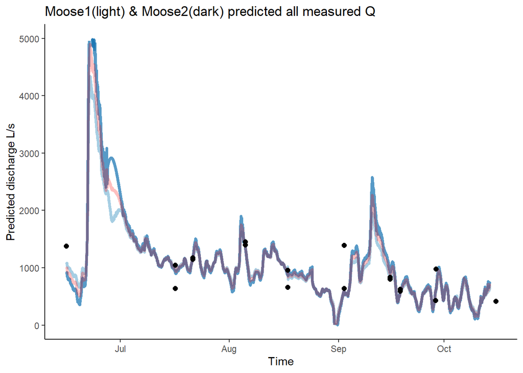

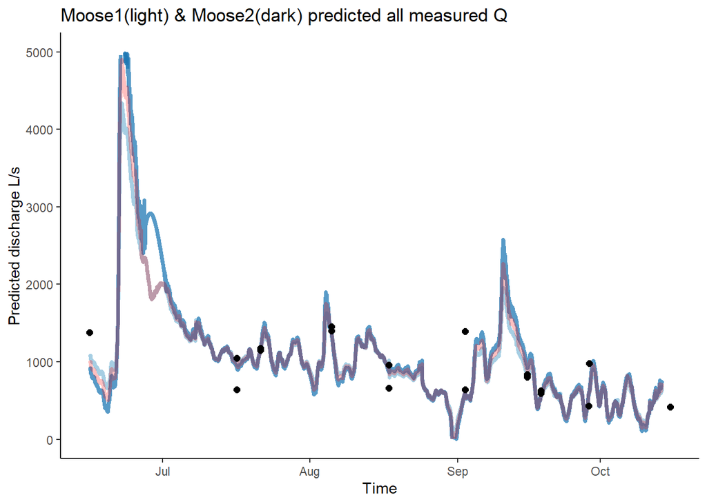

Red is the average that should be used and exported as csv.

##Export PT data to csv in DoD_Discharge->Predicted_Discharge->2020

# French

## Raw French PT1

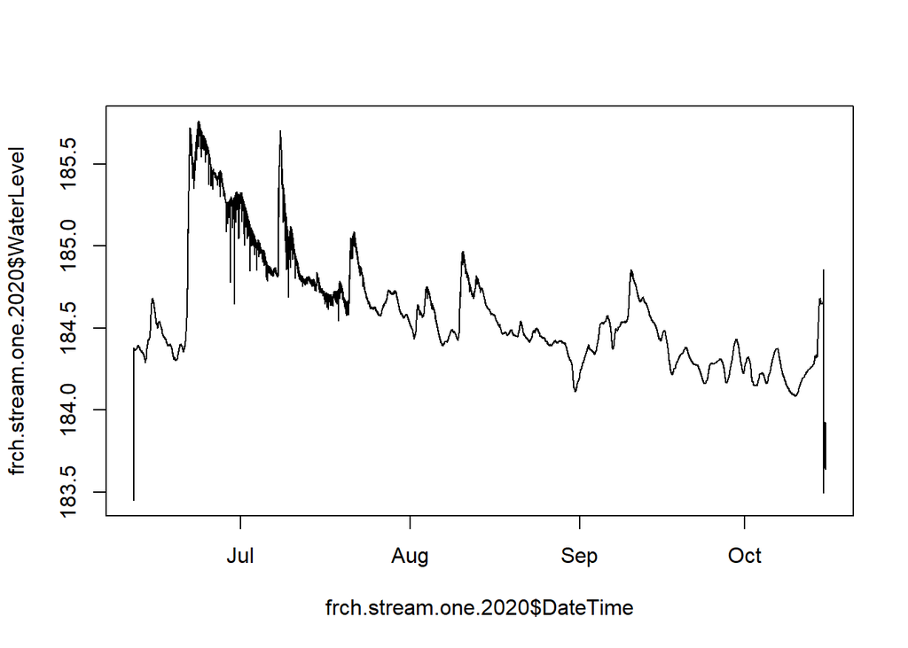

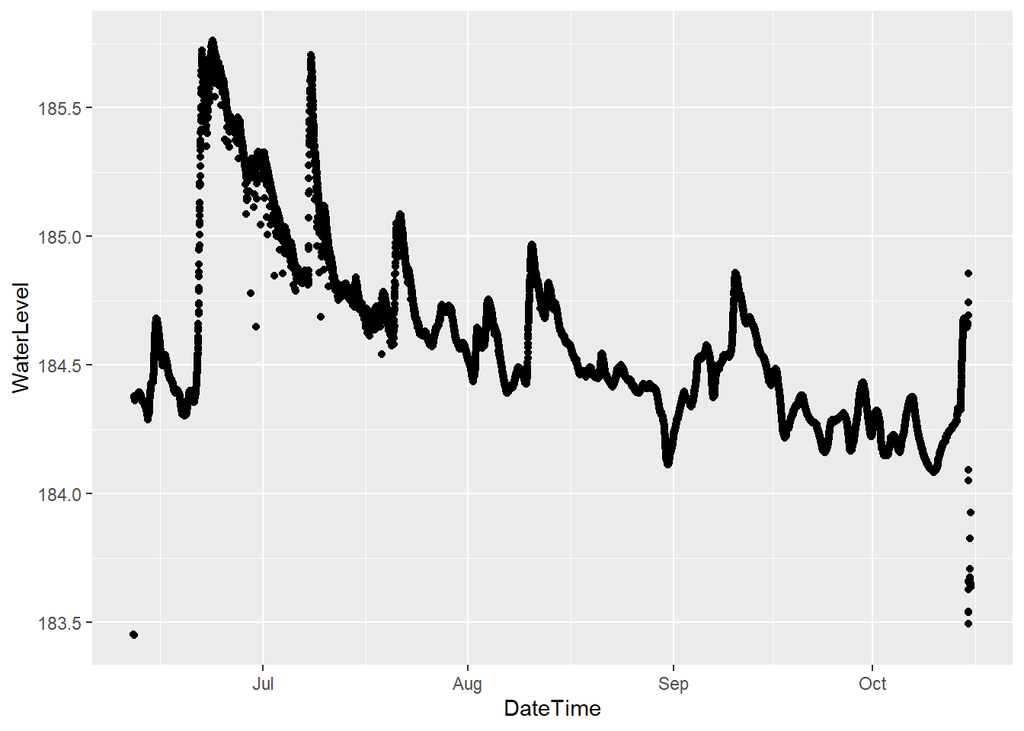

Needs cleaning for out of water points that are associated with install and decommission. Noisy on the falling limb of these storms! Let the cleaning commence!

## French PT1 2.0

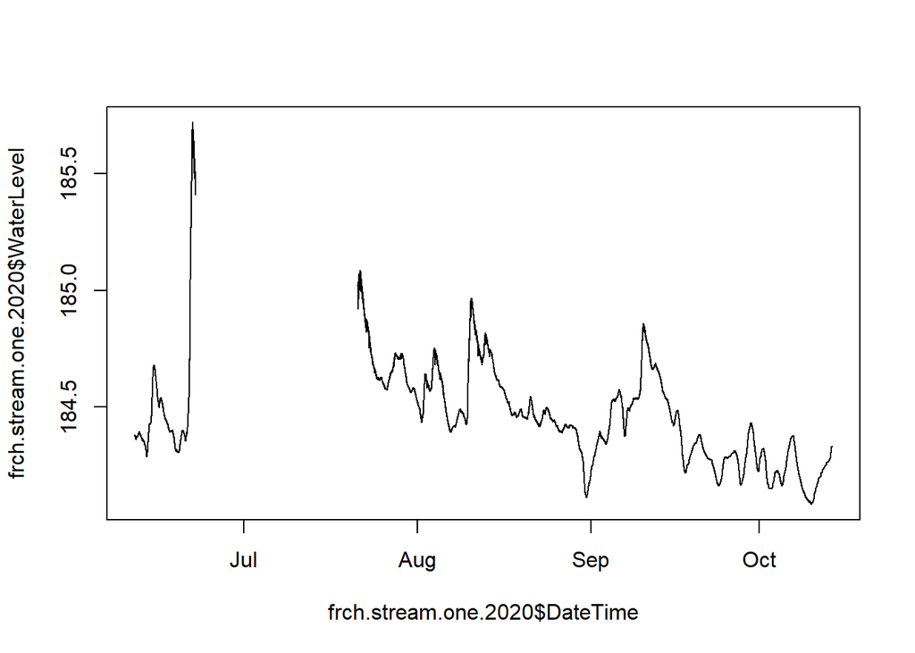

1. Removed points after October 14th (when we took out PTs) and out of water points in the beginning of the dataset
2. Removed noisy points on receding limb of big storm events in the beginning of the dataframe

## Raw French PT2

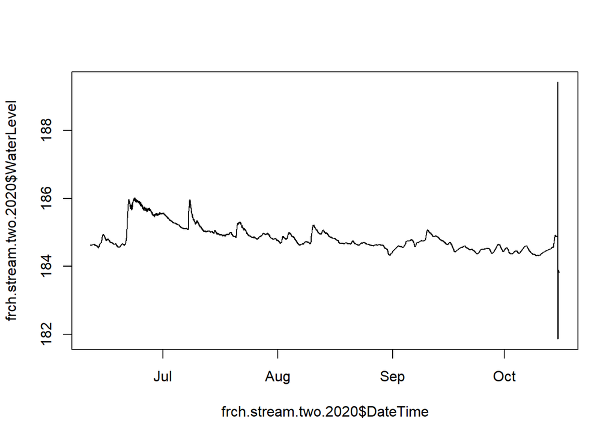

Receding limb of first initial storm is noisy on this one too

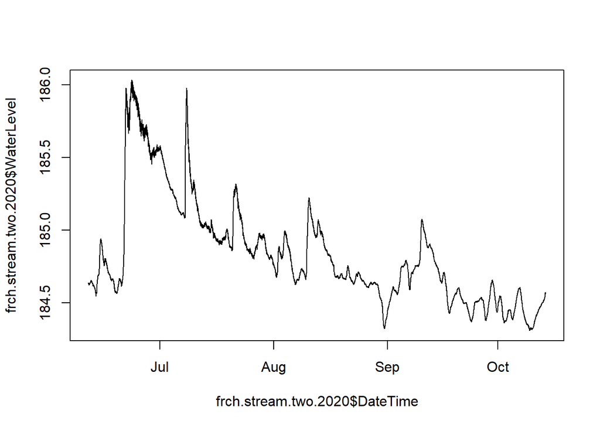

1. removed out of water points from taking out on the 14th of October

## Export PT data to csv in DoD_Discharge->PT_data->2020

## Raw Rating curve FRCH PT1

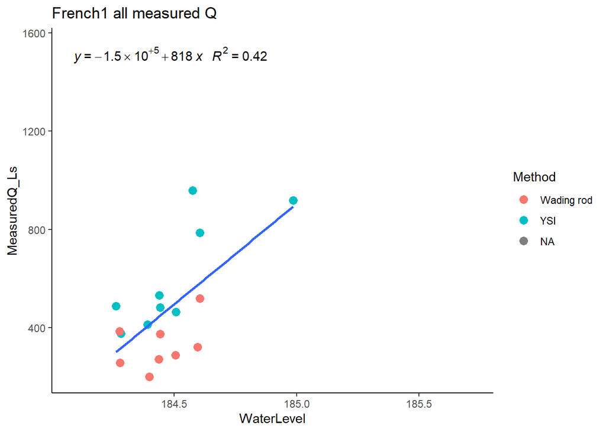

Lets remove two high YSI points.

```
##   Site          DateTimeGMT Absolute Pressure WaterLevel            DateTime
## 1 FRCH  07/09/20 9:15:00 AM           115.882         NA 2020-07-09 09:15:00
## 2 FRCH 07/16/20 10:45:00 AM           111.483         NA 2020-07-16 10:45:00
## 3 FRCH 07/21/20 10:00:00 AM           114.239    184.986 2020-07-21 10:00:00
##        Date  Time Method VolSlugml Batch MeasuredQ_Ls       date
## 1  7/9/2020  9:15    YSI      1000     B      1552.47 2020-07-09
## 2 7/16/2020 10:45    YSI      1000     B       791.43 2020-07-16
## 3 7/21/2020 10:00    YSI       500     J       919.03 2020-07-21
```

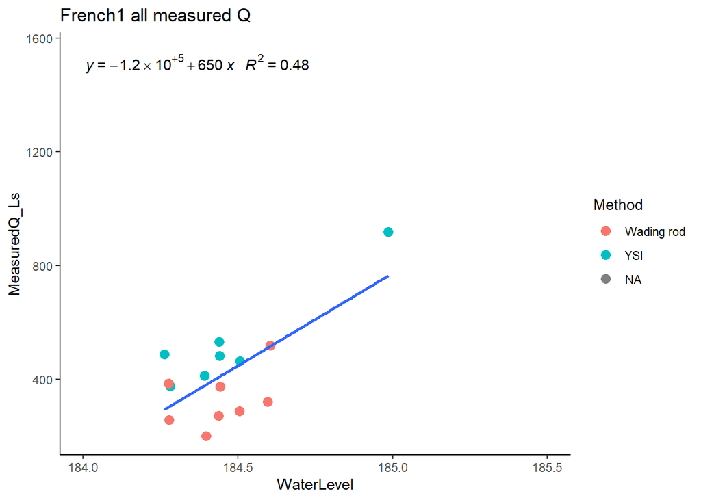

I would guess that the YSI is a little high and the wading rod is a little low. What if we average them by date? That may be more accurate than just taking the Wading rod points.

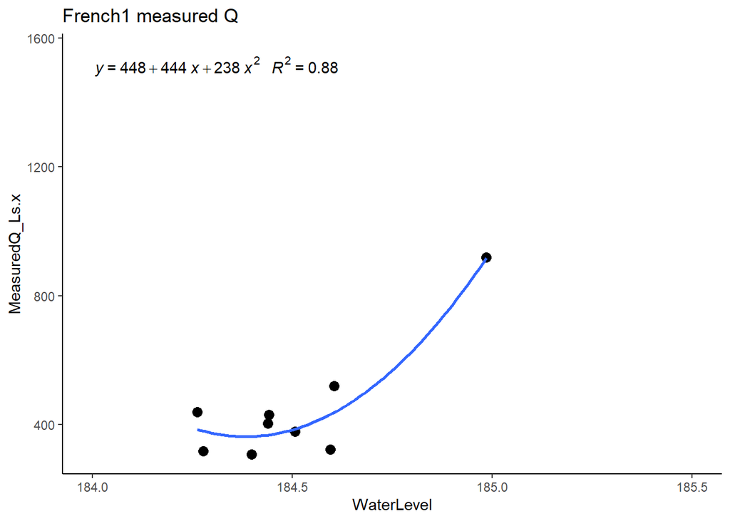

Seems reasonable. A quadratic relationship improved the R2.

## Final Q for FRCH PT1

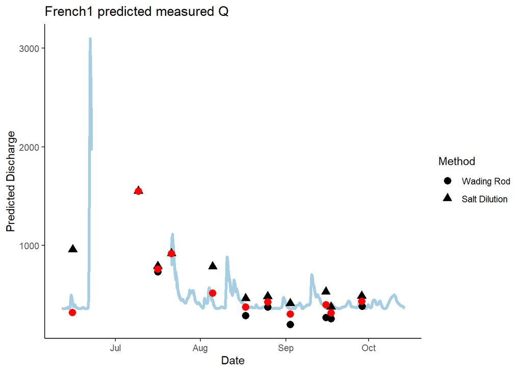

Red are the points used in the rating curve (if they had pressure data).

## Raw Rating curve FRCH PT2

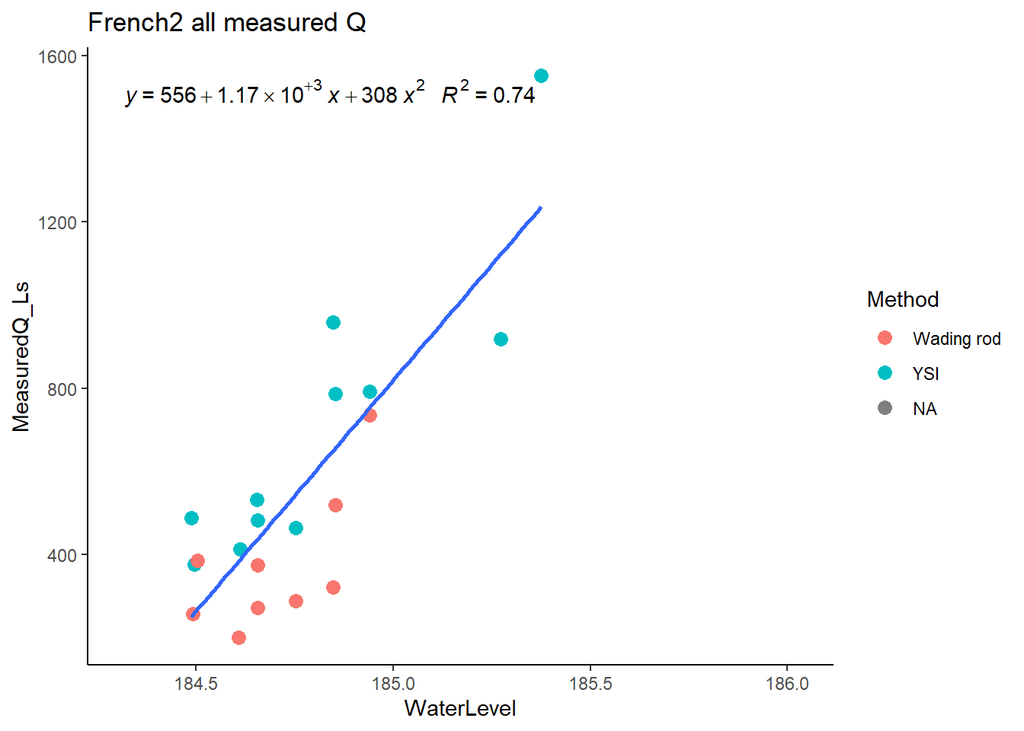

Lets remove the highest YSI points, then only use the wading rod and next highest YSI point.

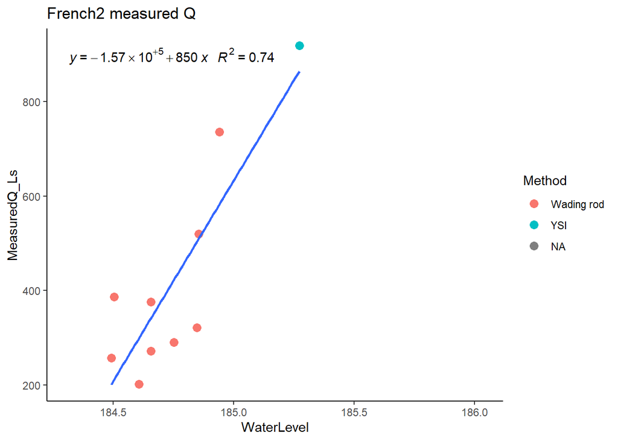

Lets try the same averaging proccess as before.

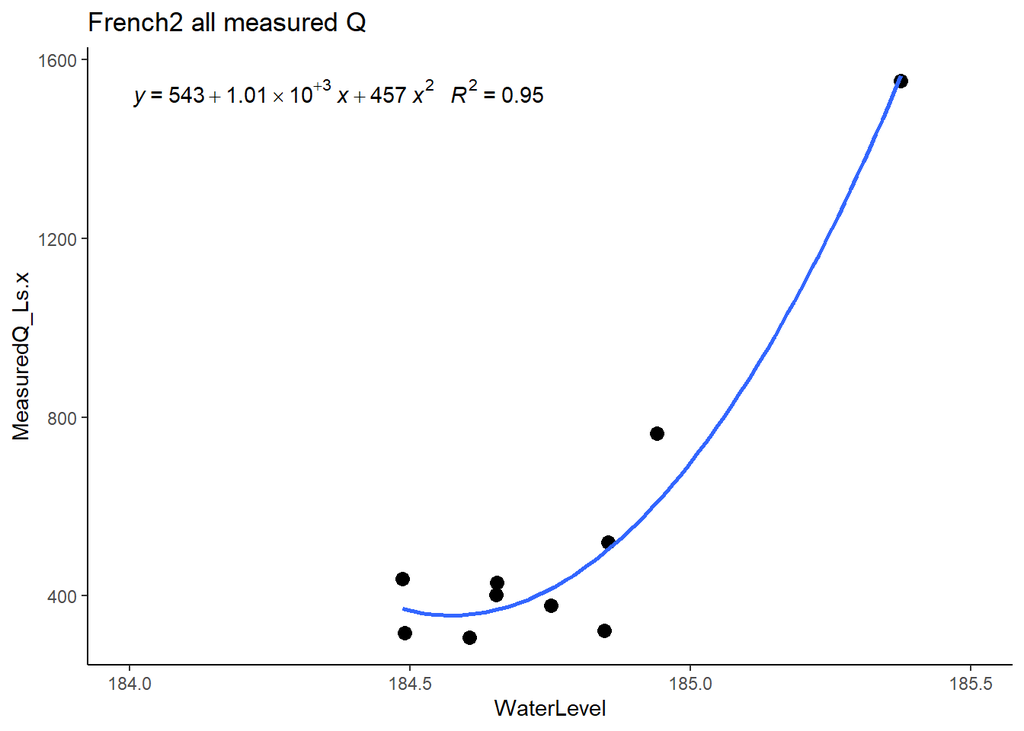

## Final Q for FRCH PT2

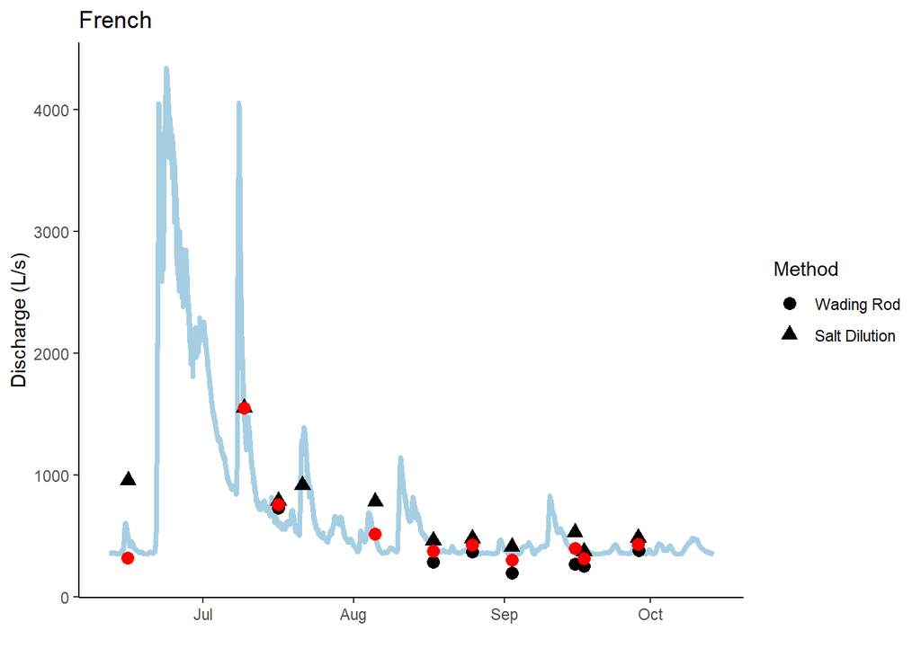

Looks pretty good

## Average Q for FRCH PT1

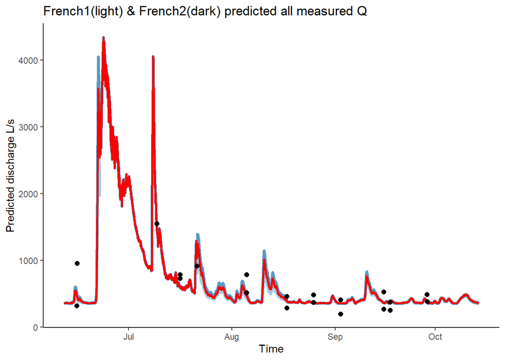

Red is the average and should be exported to a csv.

## Export PT data to csv in DoD_Discharge->Predicted_Discharge->2020

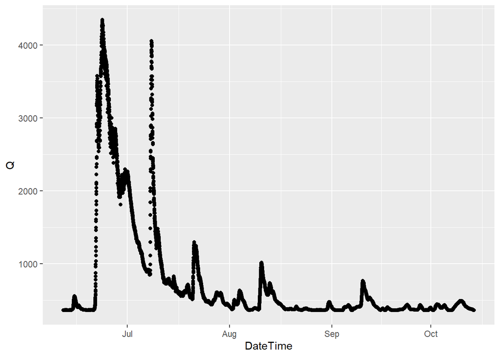

# Poker

## Raw Poker PT1

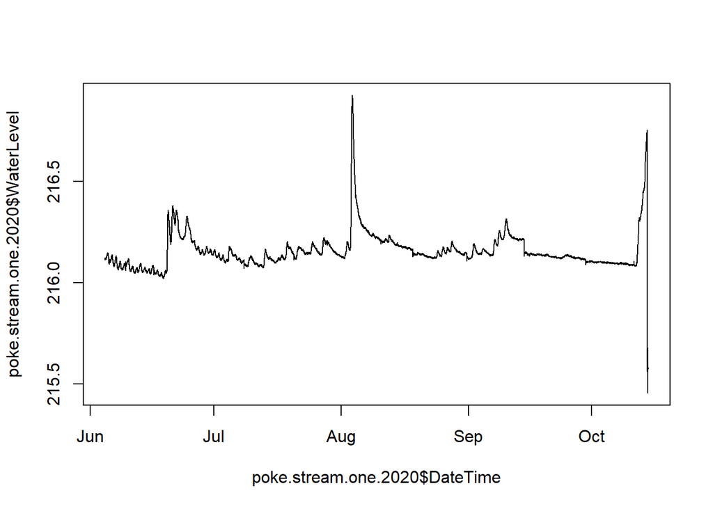

It looks like I need to remove out of water points at the end of the year and potentially shift middle of september-on up….let the cleaning commence!

Poker PT1 2.0

```
## [1] 0.068
```

[output not shown]

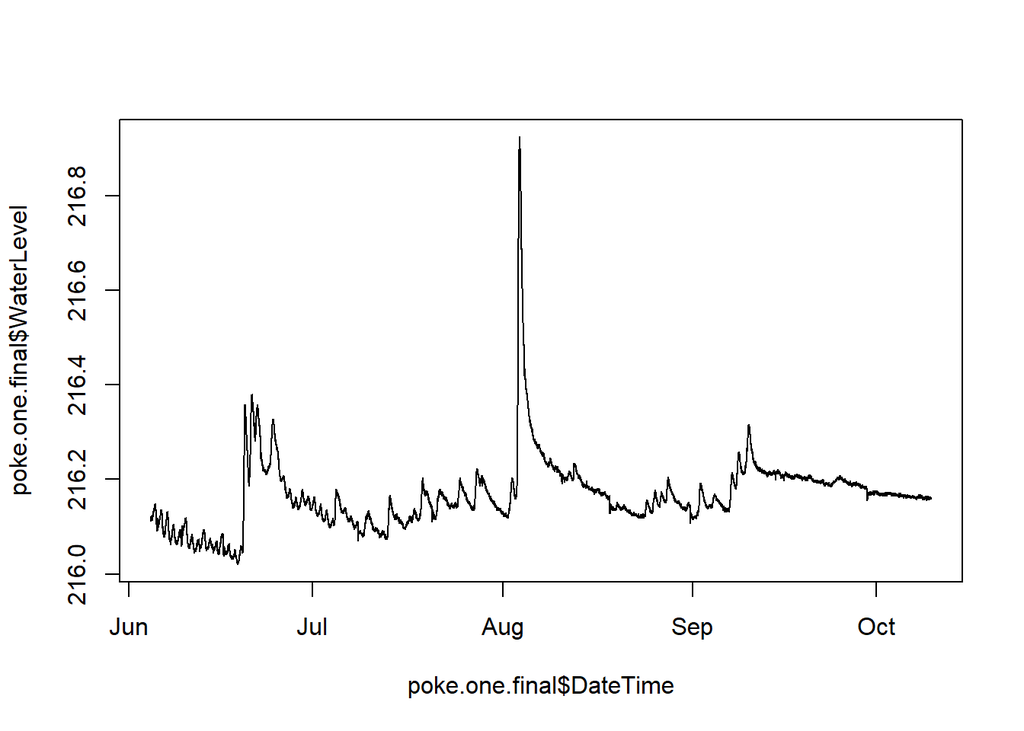

1. removed data after 10/10/20 due to decommission
2. shifted mid september-on up due to dip

## Raw Poker PT2

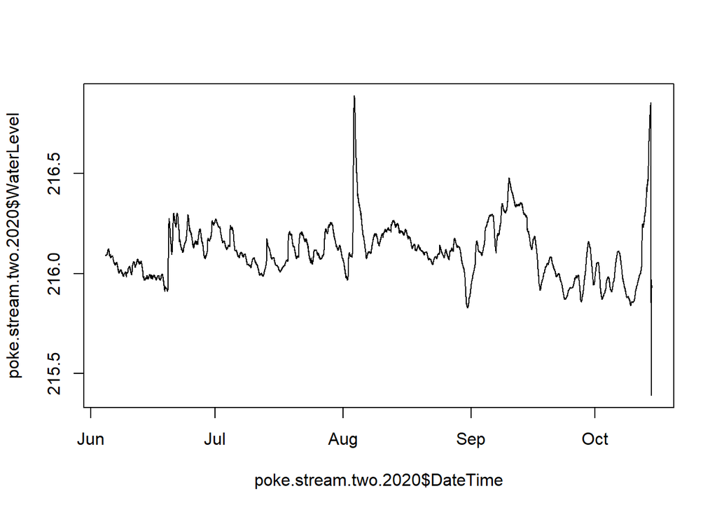

PT2 seems a lot “noisier”….this is the PT that is located on the wetttetd edge left side tucked by the meander so it is more susecptible to shaking….It also needs to be filtered out at the end of the season due to out of water points….let the cleaning commence!

Poker PT2 2.0

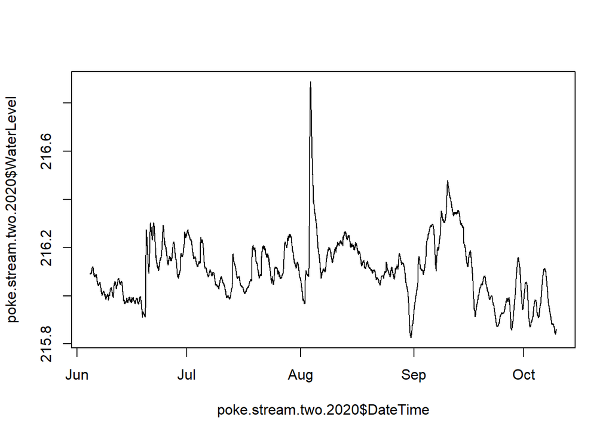

## Export PT data to csv in DoD_Discharge->PT_data->2020

## Raw Rating curve POKE PT1

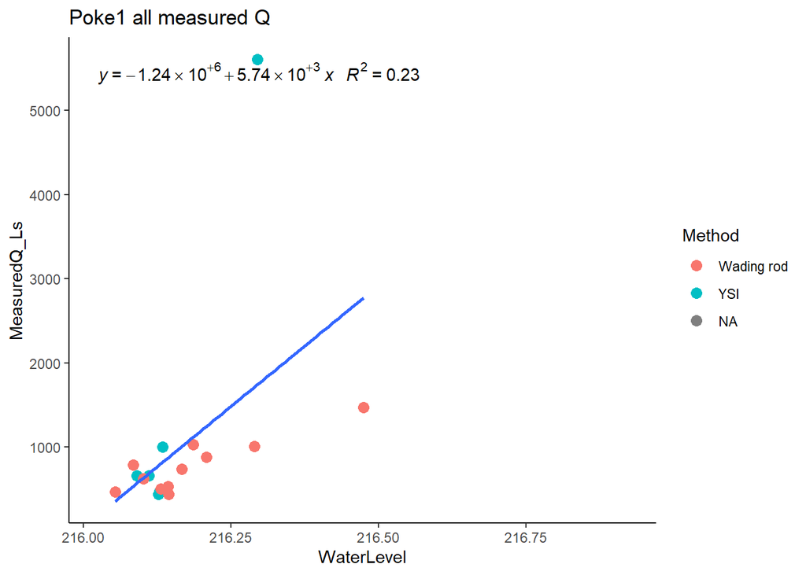

top YSI point has got to go

Rating curve POKE PT1 2.0

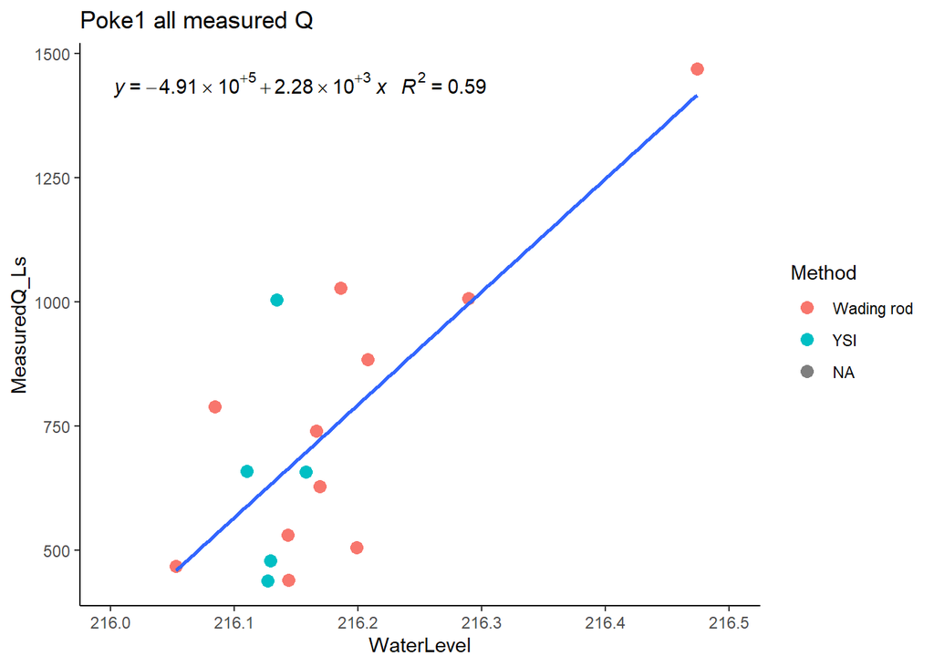

1. removed the top YSI point

## Raw Rating curve POKE PT2

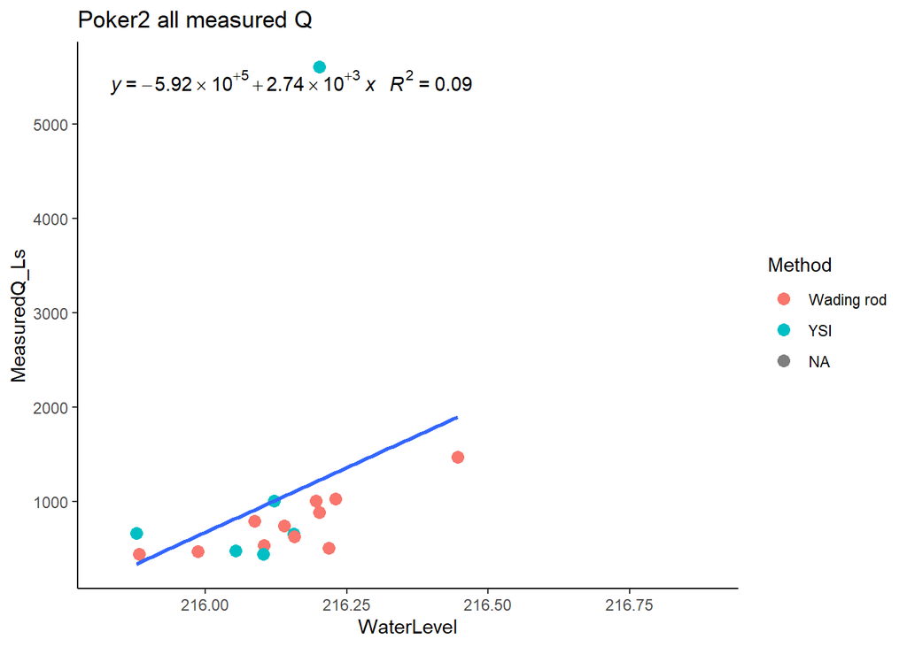

Need to remove the top YSI point and lowest water level YSI point.

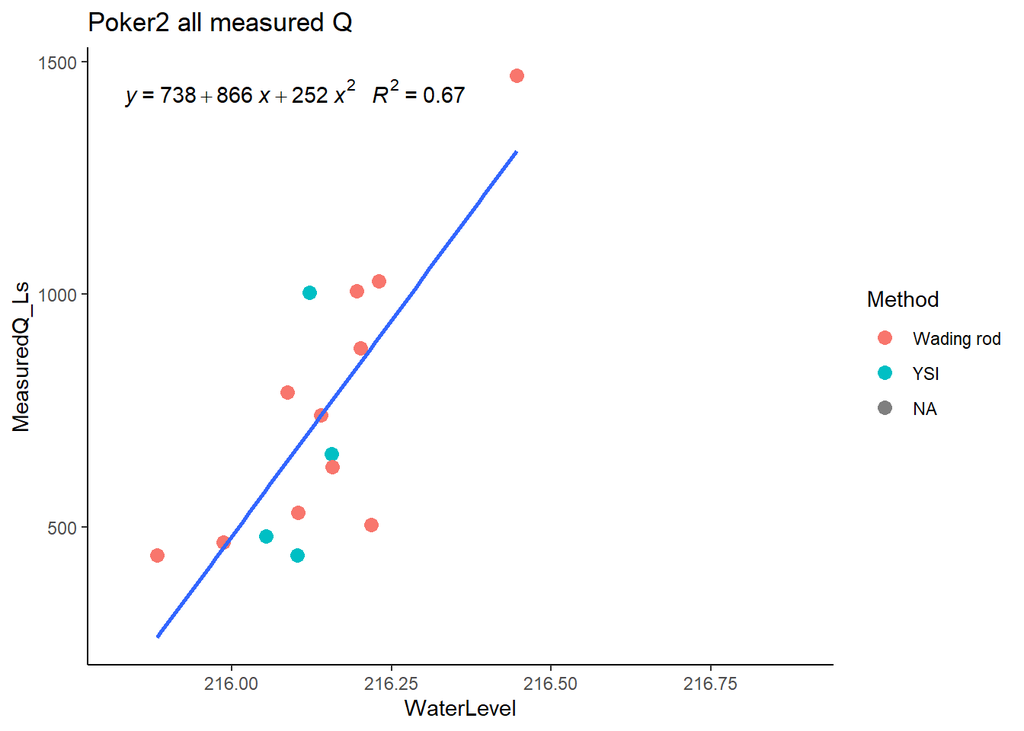

1. removed the top YSI point
2. Quadratic is a slightly better fit.

## Final Q for POKE PT1

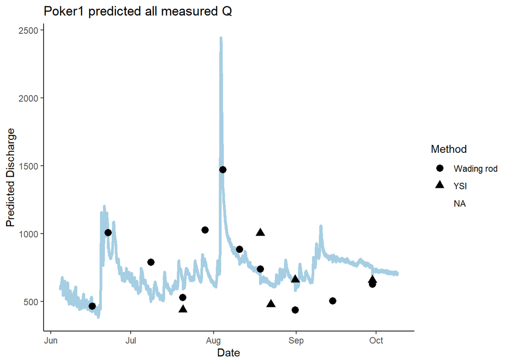

Seems like the predicted overshoots our discrete measurements

## Final Q for POKE PT2

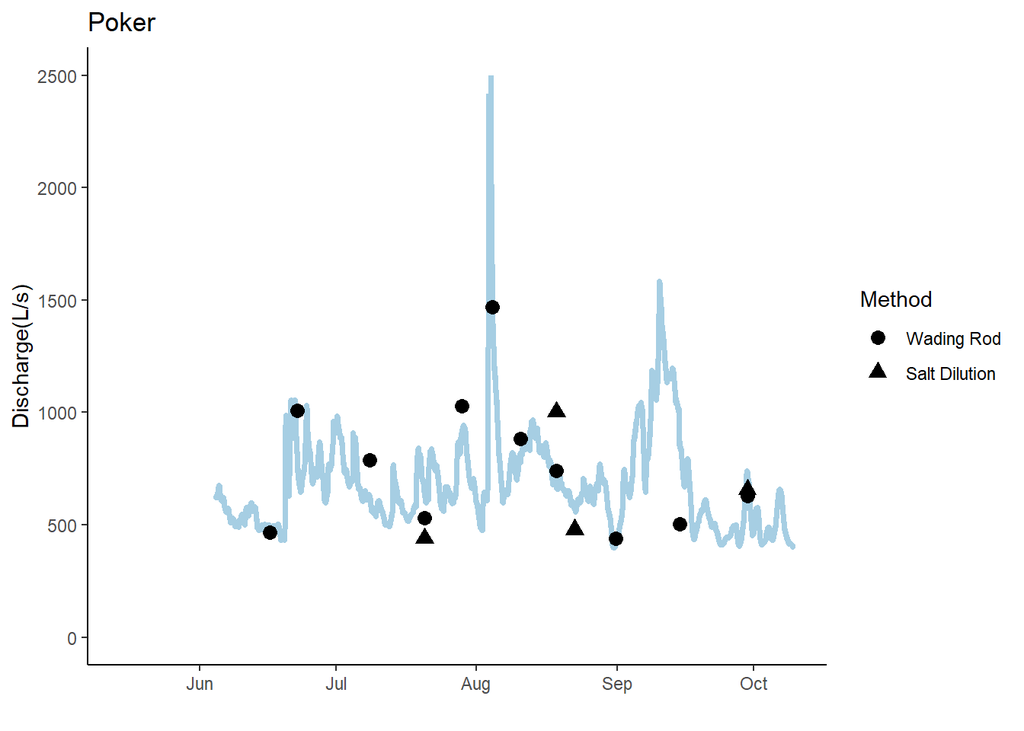

A lot noisier then PT1.

## Final Q POKE average

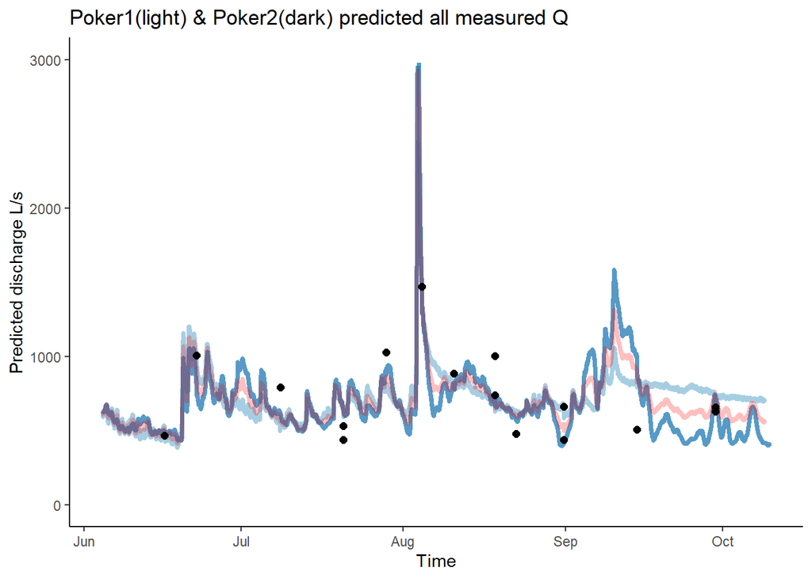

I think we should go with PT1

## Export PT data to csv in DoD_Discharge->Predicted_Discharge->2020

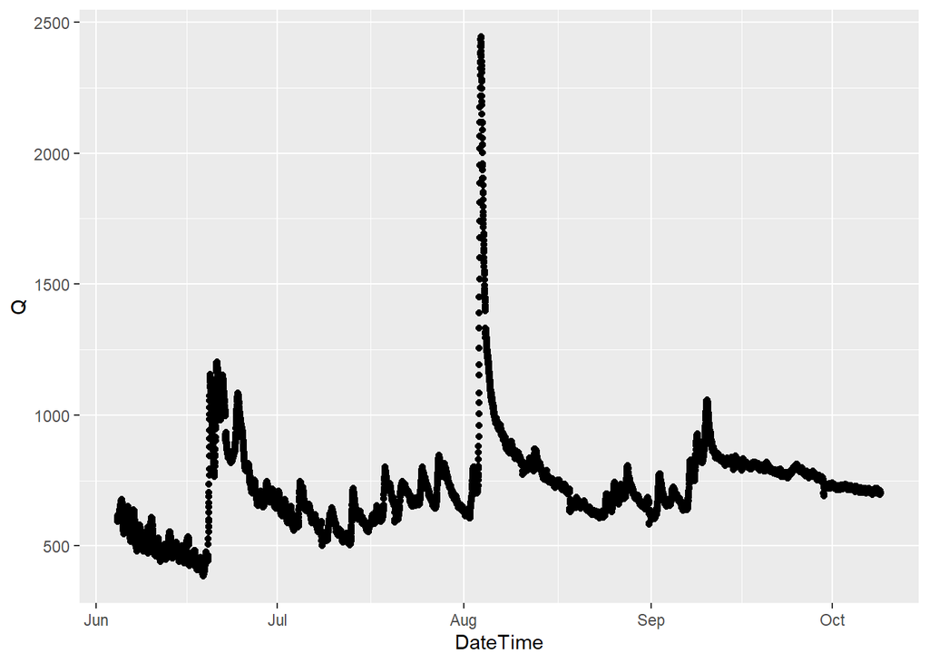

# Vault

## Raw Vault PT1

There is only one Vault PT

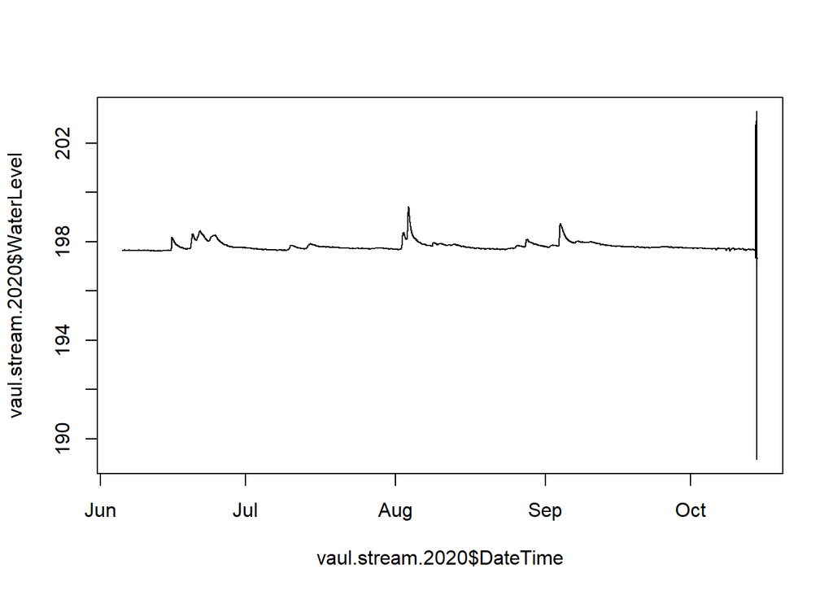

Hard to see what else we need to clean besides the end of the year out of water points….let the cleaning commence!

## Vault PT1 2.0

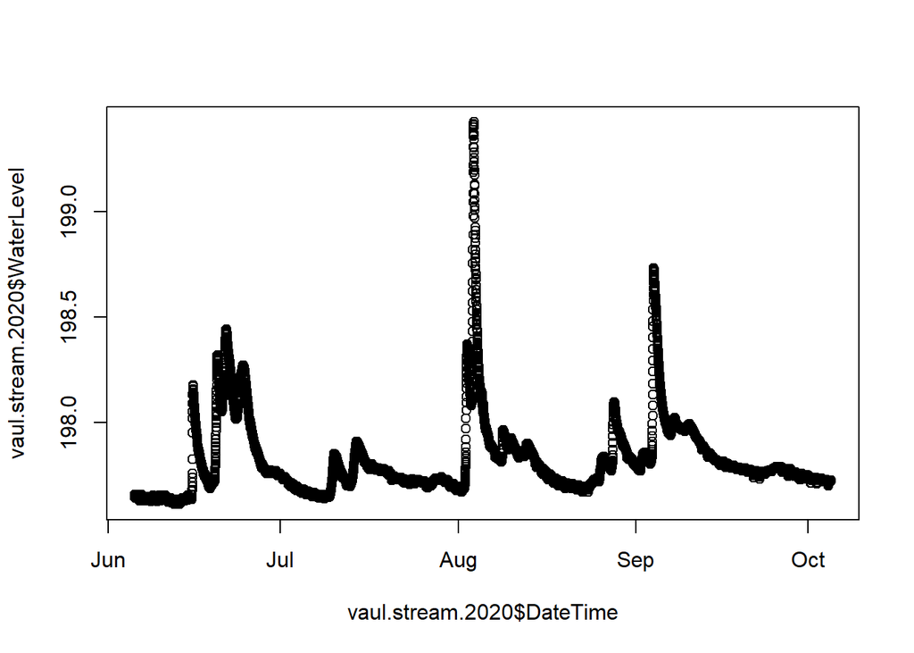

1. removed data after 10/5/20 due to out of water points

## Export PT data to csv in DoD_Discharge->PT_data->2020

## Raw rating curve for VAUL PT1

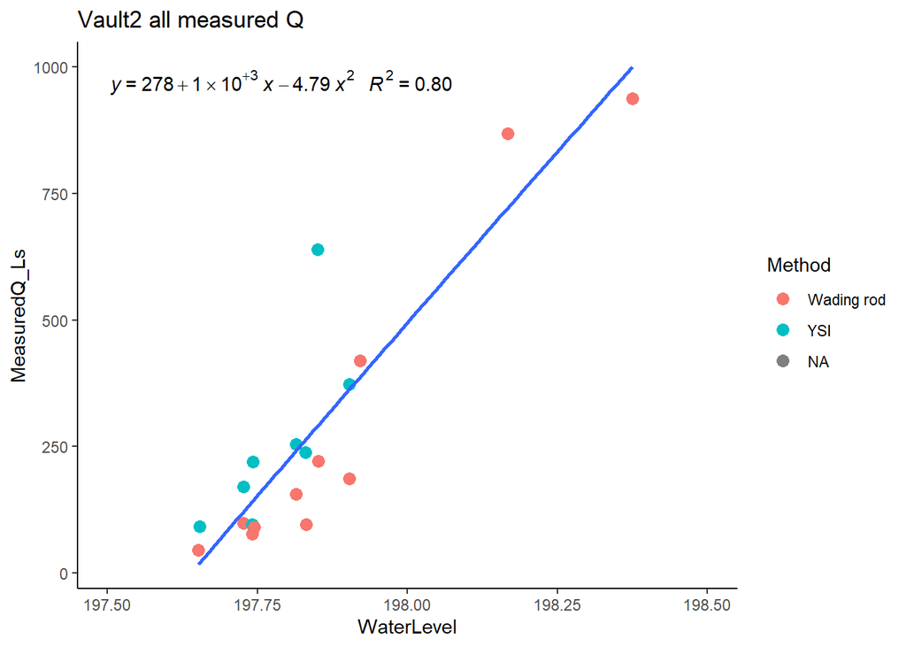

## Predicted Q for VAUL

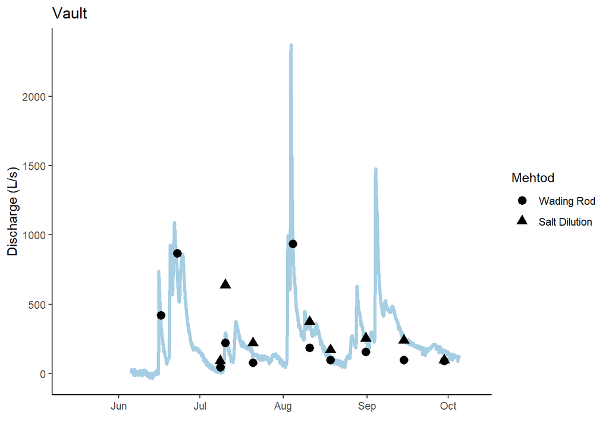

Not too shabby!

## Export PT data to csv in DoD_Discharge->Predicted_Discharge->2020

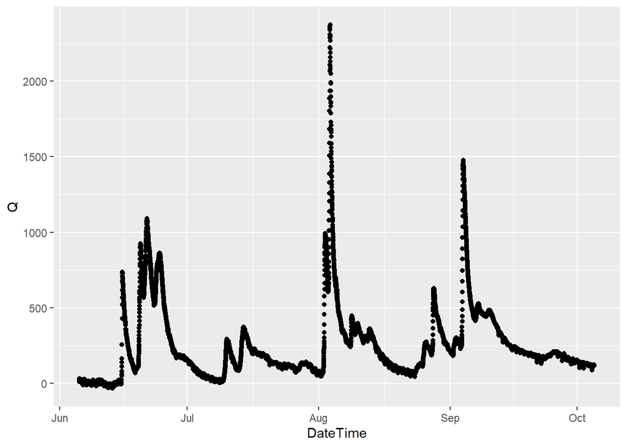

# Stuart

## Raw STRT PT1

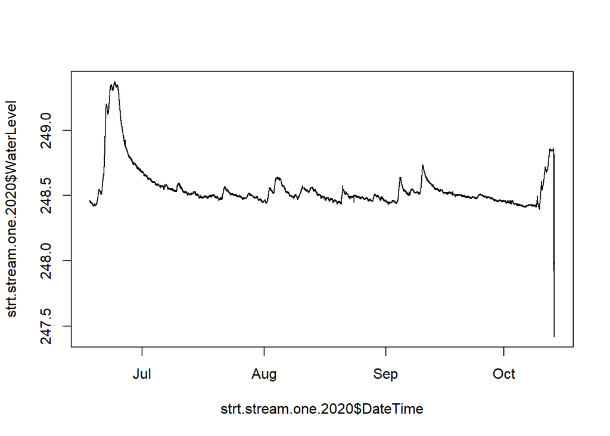

Needs end of season out of water points to be removed….let the cleaning commence!

STRT PT1 2.0

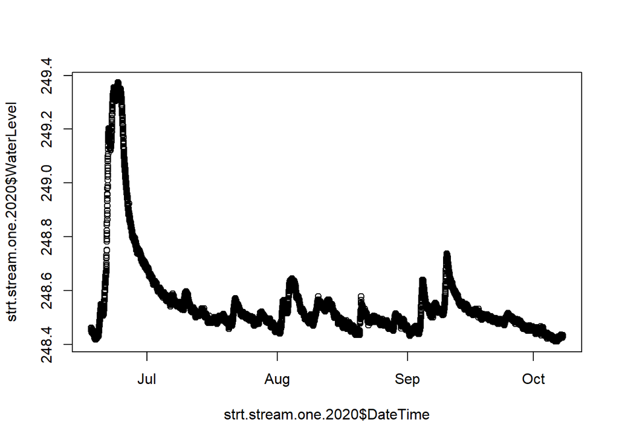

1. Removed data after 10/8/20 due to ice on the channel…PT was taken out on the 13th
2. removed vertical bar errant point in middle of August

## Raw STRT PT2

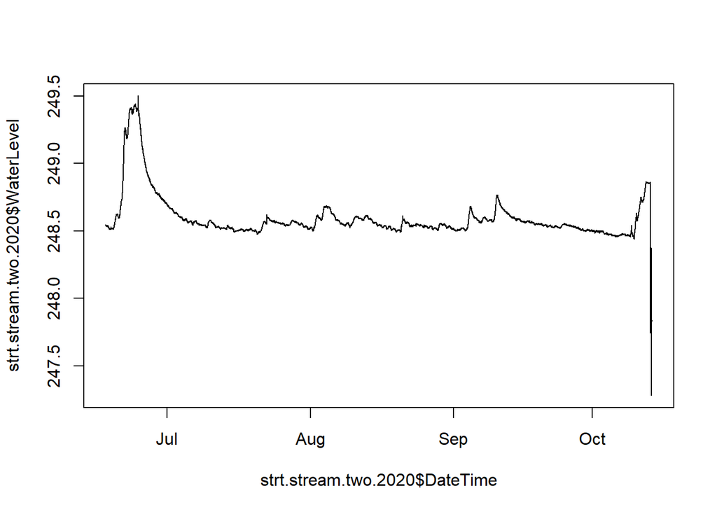

Same procedure as previous PT….let the cleaning commence!

STRT PT2 2.0

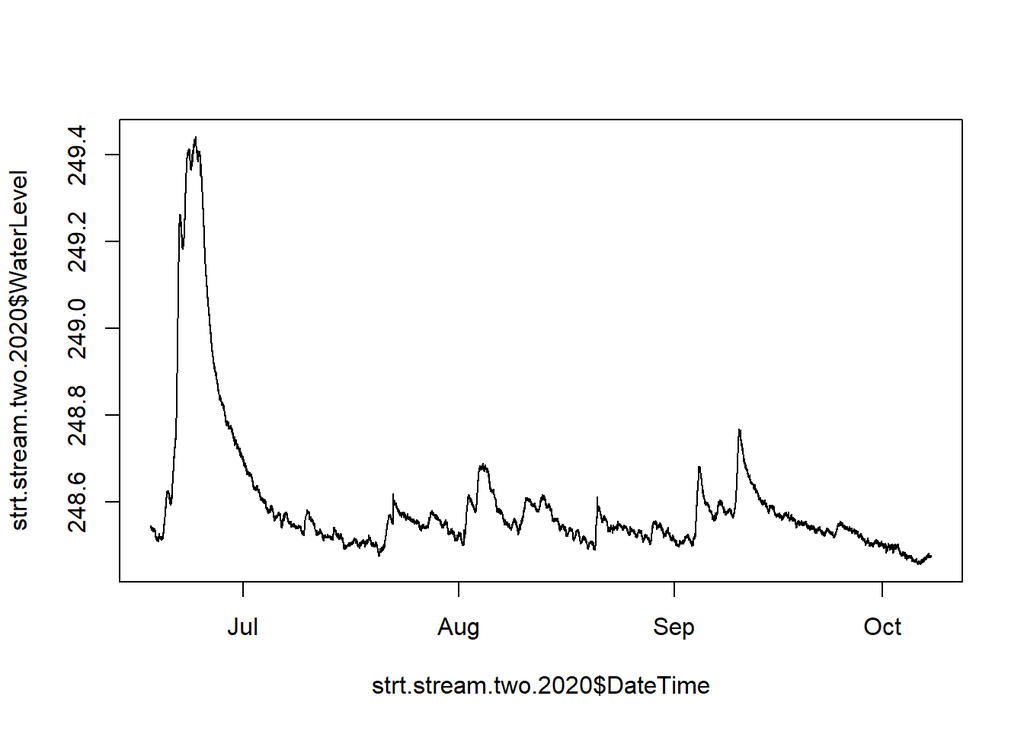

1. Removed vertical errant point at the top of first big storm
2. Removed data after 10/8 due to ice on the channel…PT was taken out on the 13th

## Export PT data to csv in DoD_Discharge->PT_data->2020

## Raw rating curve for STRT PT1

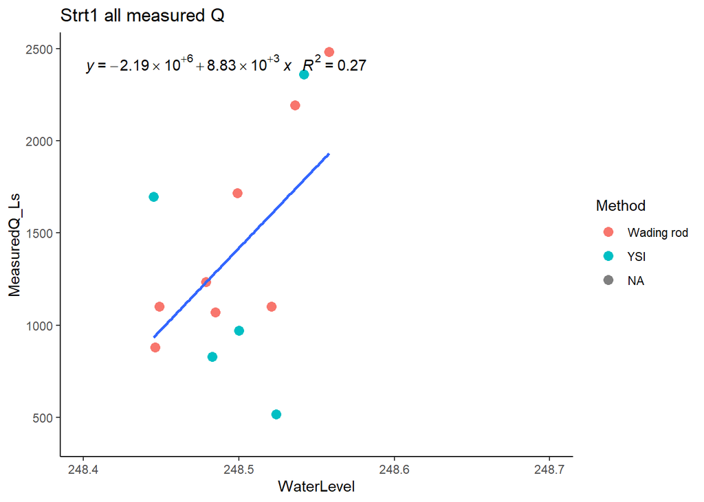

Does not look pretty

## Rating curve for STRT PT1 2.0

```
##
## Call:
## lm(formula = Strt1comb.2020$MeasuredQ_Ls ~ Strt1comb.2020$WaterLevel)
##
## Residuals:
##    Min     1Q Median     3Q    Max
## -548.2 -157.1  106.0  198.8  356.1
##
## Coefficients:
##                           Estimate Std. Error t value Pr(>|t|)
## (Intercept)               -3765764     696366  -5.408 0.000640 ***
## Strt1comb.2020$WaterLevel    15160       2802   5.410 0.000638 ***
## ---
## Signif. codes:  0 '***' 0.001 '**' 0.01 '*' 0.05 '.' 0.1 ' ' 1
##
## Residual standard error: 317.6 on 8 degrees of freedom
##   (10775 observations deleted due to missingness)
## Multiple R-squared:  0.7853, Adjusted R-squared:  0.7585
## F-statistic: 29.27 on 1 and 8 DF,  p-value: 0.0006385
```

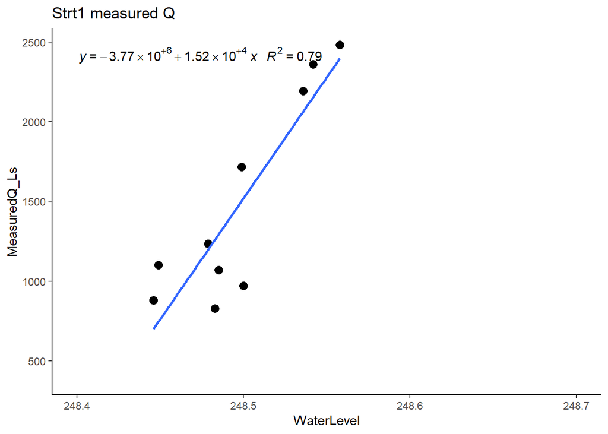

## Raw rating curve for STRT PT2

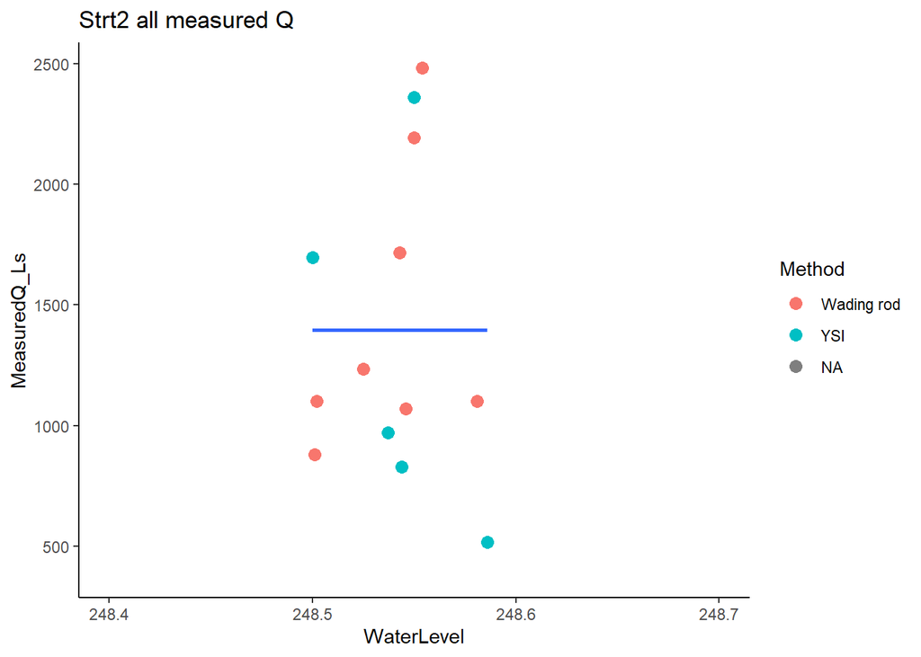

Rating curve for STRT PT2 2.0

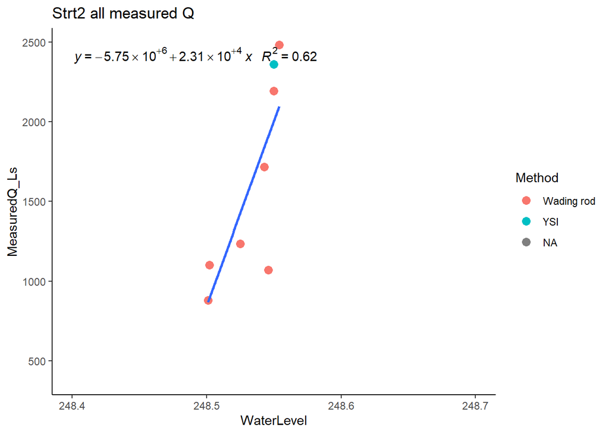

Yikes.